# An Exploration of Diversity & Inclusion in the U.S. Military

William Stricklett

Research question: How diverse is the US military?

In order for the US military to face challenges across the globe, it must be epuipped with a perspective that is representative of the globe and all of its people. The data set I will be exploring is an excel file that contains demographic breakdowns of every rank in each branch of the US military. Each person is identified based on gender and race. The dataset contains separations between branches, but it also includes a table on the U.S. military as a whole. It contains data on active duty and reserve, but this analysis will only explore the active duty population. It was obtained through the data.gov data set catalogue through this link: https://catalog.data.gov/dataset/personnel-trends-by-gender-race. It is a U.S. government work and it was published by the Department of Defense, meaning that the dataset was produced by a government employee as a part of their official duty. The dataset is reliable as it was created by the U.S. government, however it was published in 2010 so the data may not be current.

In the excel file, the US Military is represented by four branches of the Department of Defense: the Army, the Navy, the Marine Corps, and the Air Force. The US Space Force is too recent to be accounted for in this excel file. Within each branch, there are different forms of personnel: officer, warrant officer, and enlisted. Officers, warrant officers, and enlisted follow their own sequence of ranks as they serve time in their respective branch. Each personnel is promoted to the next rank if they stay in for long enough and complete the necessary qualifications. Or, they may decide to leave the military. The excel file categorizes each individual based on sex: male and female. Then, it categorizes them based on race: American Indian/Alaskan Native, Asian, Black, multi-race, Native Hawaiian/Pacific Islander, unknown race, or White. Then, it categorizes them based on whether or not they are Hispanic or Non-Hispanic. Hispanic includes Mexican, Puerto Rican, Cuban, Latin American with Hispanic descent and other hispanic descent. A data dictionary of the values that represent these demographic breakdowns is located in the appendix.

My intent is to explore the diversity of active duty personnel between the branches as well as the diversity of promoted and retained personnel.

Let us begin by looking at the relative diversity of each branch.

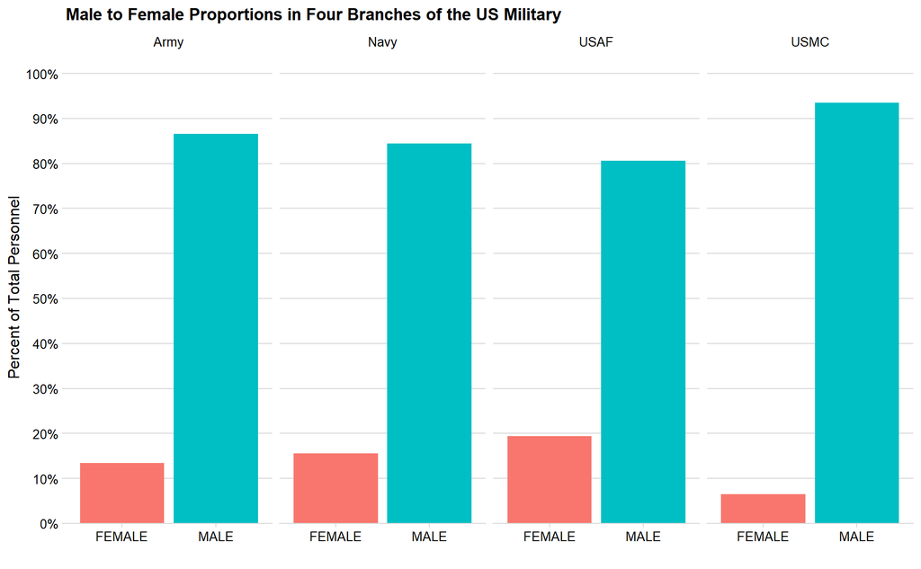

The four branches in question appear to be overwhelmingly male. The Air Force appears to have the highest percentage of females and the Marine Corps appears to have the lowest percentage of females.

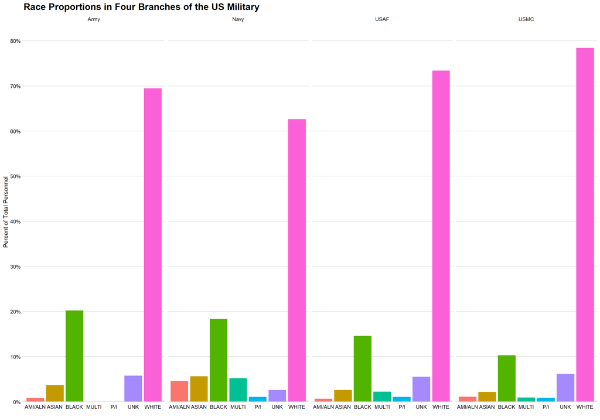

The four branches in question appear to be majority White. The Army has a very small amount of multi-racial or Pacific Islander personnel. The Navy appears to have the lowest percentage of White and the most spread out distribution of minorities, but the Army has the highest percentage of Black of all the branches.

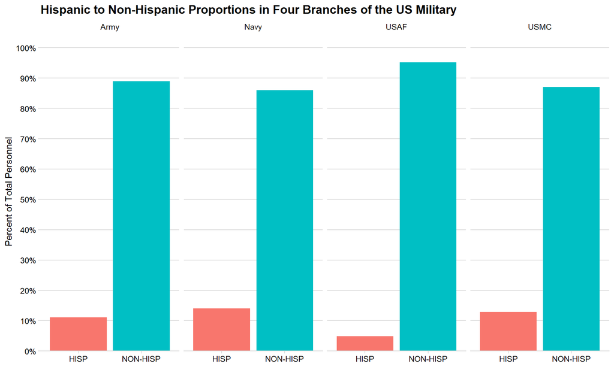

Next, let us look at the demographic breakdowns of ranks in the US military to gauge diversity as it relates to personnel promotions and retention. This analysis will explore the enlisted ranks from E1-E9. The enlisted of the four branches of the US military accounts for 83.69167% of the total active duty personnel and provides the best resolution to view the diversity breakdown of rank progression. In order to provide a fair view of varying promotion rates, the rank breakdown of each demographic category will be related to the demographic category’s portion of total personnel.

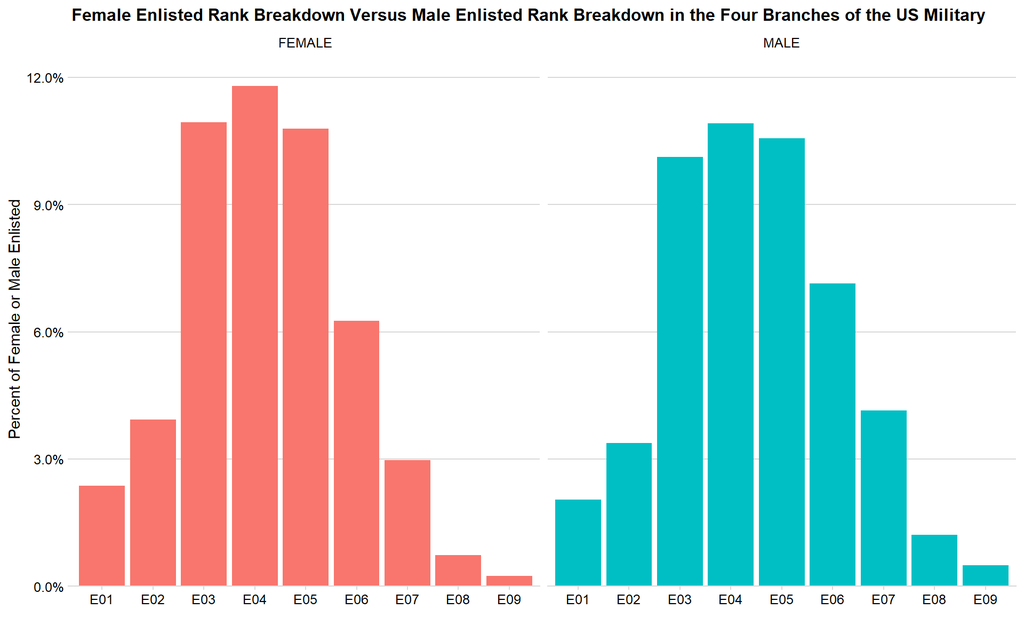

It seems that female enlisted are more concentrated in the middle ranks compared to male enlisted. More male enlisted go on to progress above the rank of E04. The difference is most significant in the E06 and E07 ranks.

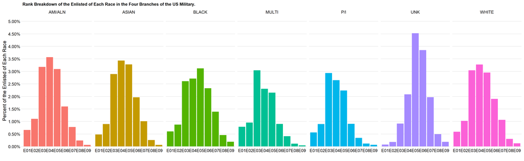

It is important to note the peak of the bar graphs where the highest concentration of enlisted in each race is present. The peak represents where most of that race’s enlisted is concentrated. American Indian/Alaskan Native appears to have the highest concentration of middle ranked enlisted. A similar amount of Asians and Whites are promoted to ranks above E04. Black have their highest concentrated enlisted in the E05 rank, which is higher than most. Multi-racial and Pacific Islander have similar concentration at the E03 rank and follow a similar retention rate to the higher ranks. White has a fairly even bell-curved distribution amongst its enlisted ranks with a slight right skew towards the higher ranks.

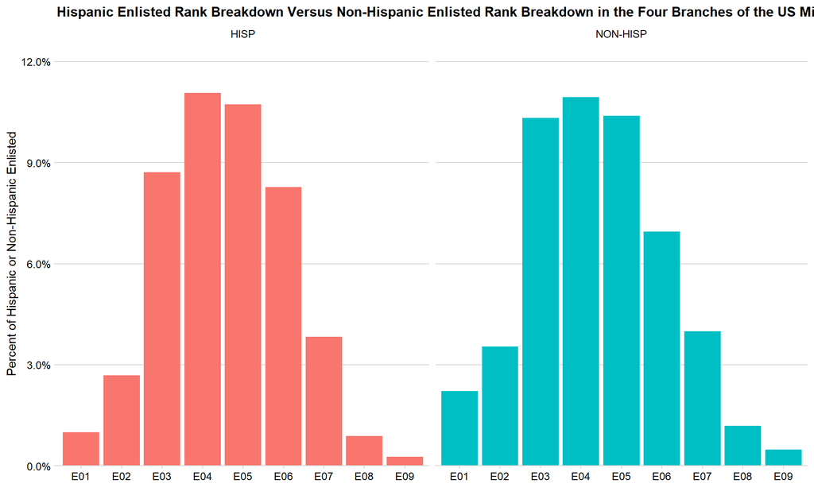

Since this data is a snapshot of the US military in 2010, exploring the diversity incoming personnel each year is not in the bounds of this data and must be considered for further research. It would be interesting to see how these demographic distributions have changed over the last ten years.

Appendix:

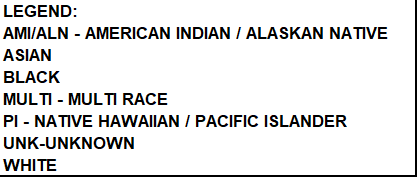

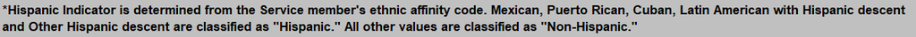